# Week Nine: Inference for Linear Regression

Welcome!

In this week’s coursework we are putting all of the pieces we’ve learned together: linear regression, confidence intervals, and p-values! We are going to use your knowledge of linear regression to make inferences about the value of the population slope.

We are going to use permutation distributions to obtain other slope statistics that we could have observed **if the null hypothesis was true**. We are going to use bootstrap distributions to obtain other slope statistics we could have observed from repeated samples from the population. Then, we will use these distributions to make inferences about the value of the population slope ($\beta$).

## Learning Outcomes

By the end of this coursework you should be able to:

- outline what hypotheses we use to test for a linear relationship
- describe how a permutation distribution for a slope statistic is made
  - connect the null hypothesis with how observations are permuted
- describe how a bootstrap distribution for a slope statistic is made
- interpret a p-value in the context of a linear relationship
- interpret a confidence interval in the context of a linear relationship
- explain the similarities and differences between parametric ($t$-based) methods and non-parametric (simulation-based) methods
- use R to:
  - generate a permutation distribution for a slope
  - visualize the permutation distribution
  - calculate the observed slope statistic
  - calculate a p-value for a hypothesis test
  - generate a bootstrap distribution for a slope
  - visualize the bootstrap distribution
  - calculate the resulting confidence interval
  - fit a linear regression
  - obtain a regression table from a linear model

## This Week’s TODOs

📖 Reading: 60 - 75 minutes

📸 Video: 8 minutes

🗞 Group Concept Questions: 8 questions

✅ Check-ins: 2

# Hypothesis Tests

📖 [**Required Reading:** *Modern Dive*, Inference for Regression](https://moderndive.com/10-inference-for-regression.html)

The TODO tasks are broken up by the section of the textbook. Each section has either (1) group concept questions or (2) check-in questions.

## Section 10.1 - Regression Refresher

### 📰 Group Concept Questions

1. What parameter are we (typically) interested in for linear regression? What symbol do we use to notate this parameter?

## Section 10.2 - Interpreting Regression Tables

### 📰 Group Concept Questions

2. What does the “standard error” output in the regression table *mean*? i.e. What does this value represent?
3. How is the “statistic” in the regression table found? How does this differ from the observed slope?
4. The null hypothesis for testing a slope is $\beta = 0.$ What does this hypothesis *mean* (i.e. what are you testing)?

### ✅ Check-in: Interpreting Regression Tables

1. In a regression table, what does the “std_error” value associated with the slope represent?
- the estimated standard deviation of the sampling distribution
- the standard deviation of the sample
- the standard error of the sample
- the standard deviation of the bootstrap distribution
2. In a regression table, how is the “std_error” value calculated?
- the standard deviation of the sample
- a mathematical formula
- the standard deviation of the bootstrap distribution
3. In a regression table, what is the “statistic” value associated with the slope?
- the sample slope
- a $t$-statistic
- a bootstrap statistic
- a $z$-statistic
4. In a regression table, how is the p-value calculated?
- using a $t$-distribution
- using a permutation distribution with 1000 resamples
- using a bootstrap distribution with 1000 resamples
- using a Normal distribution
5. What percentage confidence interval is output in a regression table?
- 90%
- 95%
- 99%

## Section 10.3 - Conditions for Inference for Regression

### 📸 Independence Violations

Video link: http://somup.com/crX20q0hwW

### 📰 Group Concept Questions

5. Can we ever *prove* that these conditions for inference are “met”? Why or why not?

### ✅ Check-in: Conditions for Inference

1. What are the required conditions for linear regression?
- linear relationship between $x$ and $y$
- a random sample was taken
- independence of variables
- independence of observations
- a large sample was collected
- normality of residuals
- normality of observations
- equal variance of residuals
2. Which of the following would violate the condition of independence?
- repeated observations on the same person
- collecting a non-random sample
- observations are related in time (temporal correlation)
- observations are geographically related (spatial correlation)
- observations are biologically related
3. Which of the following would violate the condition of normality?

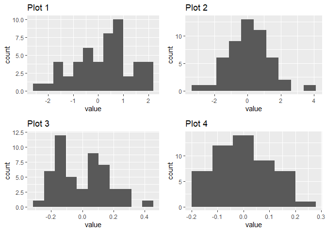

4. Which of the following would violate the condition of equal variance?
- observations that (when plotted) look like a cloud of points
- observations that look like a funnel
- observations that look like a sine wave
5. What condition for inference are simulation-based methods more resistant to?

Type in the letter corresponding to the condition: L, I, N, or E.

## Section 10.4 - Simulation Based Inference for Regression

### 📰 Group Concept Questions

6. How is the p-value in the regression table found? How does this differ from simulation-based methods?
7. How is the confidence interval in the regression table found? How does this differ from simulation-based methods?
8. Why would someone choose to use simulation-based methods over theoretical ($t$-based) methods?

# Think Out Loud Recording

Describe two similarities and two differences between using simulation-based methods and theoretical methods to obtain a p-value for testing if there is a linear relationship between two variables.